# Response bias modelling

## Mixture modelling on core trials

*Core* trials made up the majority (90%; 432/480 trials) of the task. They’re what we’ve discussed in meetings so far: participants saw an equal number of trials from each cell of our 2 x 2 design (2 reward levels: low, high; 2 coherence levels: 20%, 40%).

Here, we do a mixture model: we assume that for some percentage of trials, each responder is making a genuine effort at the task, but for others, they are guessing at random. This modelling approach estimates the proportion of trials which fall into each of these categories, then estimates our parameters of interest (value bias, precision) only for the distribution of ‘genuine effort’ trials.

On this run I left in the people who we usually exclude as frequent guessers, to see if the model still fits well (by assigning them a high guessing probability).

### Does the model fit?

First, let’s visually inspect how the model is fitting relative to the observed data.

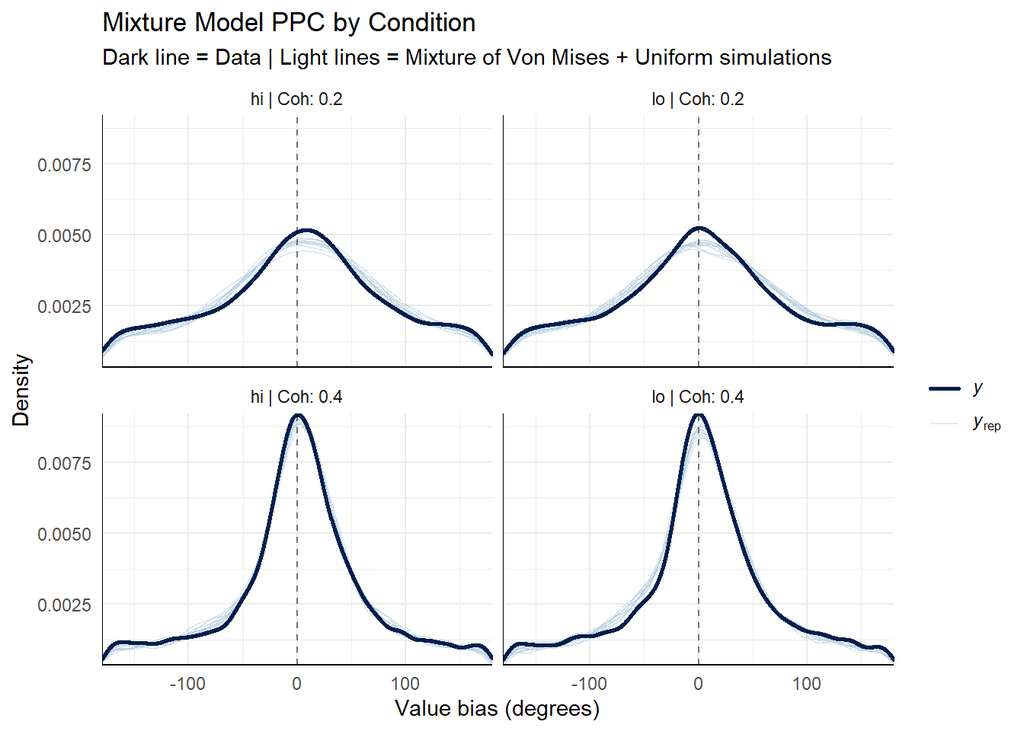

Overall, model fit is looking much better than for the simpler non-mixture version (circular response distribution with dispersion.

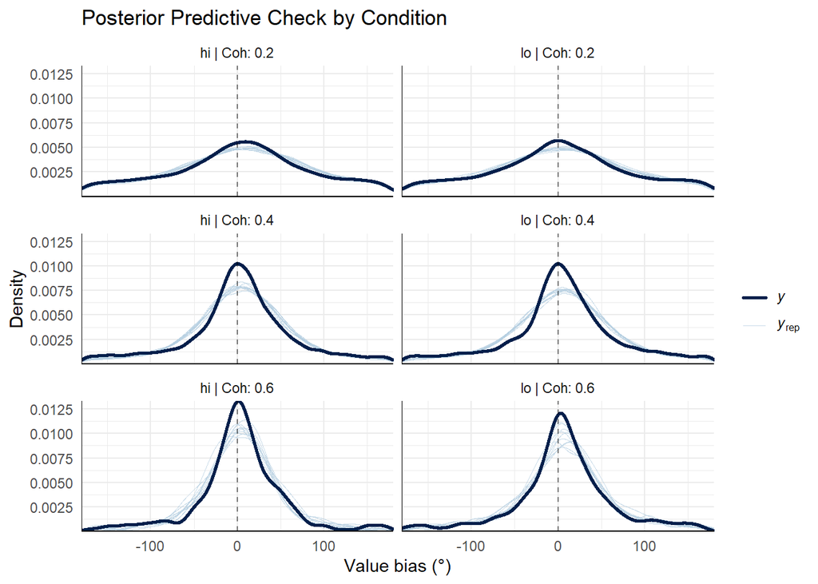

### Is a response bias present?

First let’s see how the model has estimated *mu* (mean) in each reward x coherence condition.

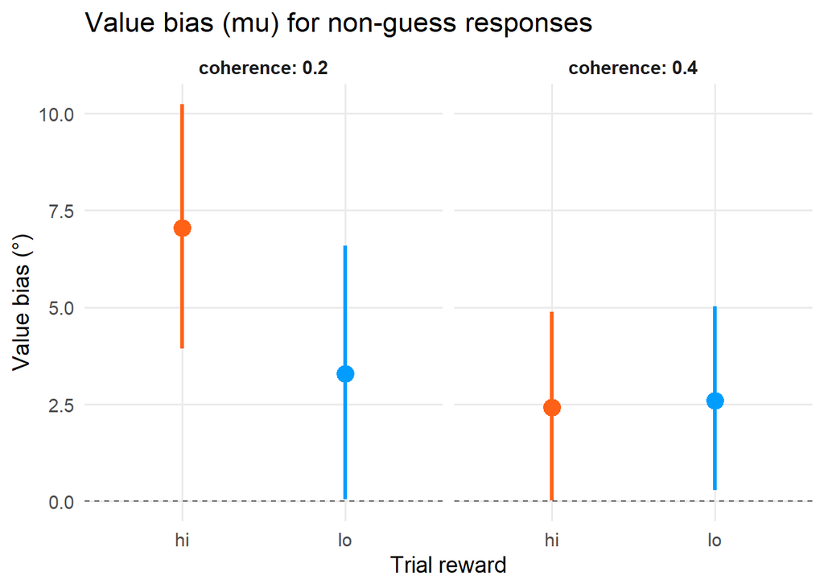

Value bisa yb condition

| Reward | Coherence | Median Bias | 95% Lower | 95% Upper | P-Directional |
| --- | --- | --- | --- | --- | --- |
| hi | 0.2 | 7.05 | 3.94 | 10.24 | 1.000 |
| hi | 0.4 | 2.42 | 0.03 | 4.88 | 0.976 |
| lo | 0.2 | 3.29 | 0.06 | 6.59 | 0.978 |
| lo | 0.4 | 2.60 | 0.29 | 5.03 | 0.985 |

Across all value x coherence combinations, there is a credible response bias. However, the ‘odd one out’ condition is low coherence/high reward, where the bias is substantially larger than for other conditions.

### How does bias change with coherence and reward?

Here, we check the posterior distributions for *differences* in response bias across levels of coherence and reward (i.e., the range of plausible values for how much the response has actually shifted). In these graphs, the plotted point is the median difference and the whiskers are the 66% (thick) and 95% (thin) credible intervals.

#### Effect of coherence

Firstly, let’s take a look at how coherence affects response bias within each level of reward.

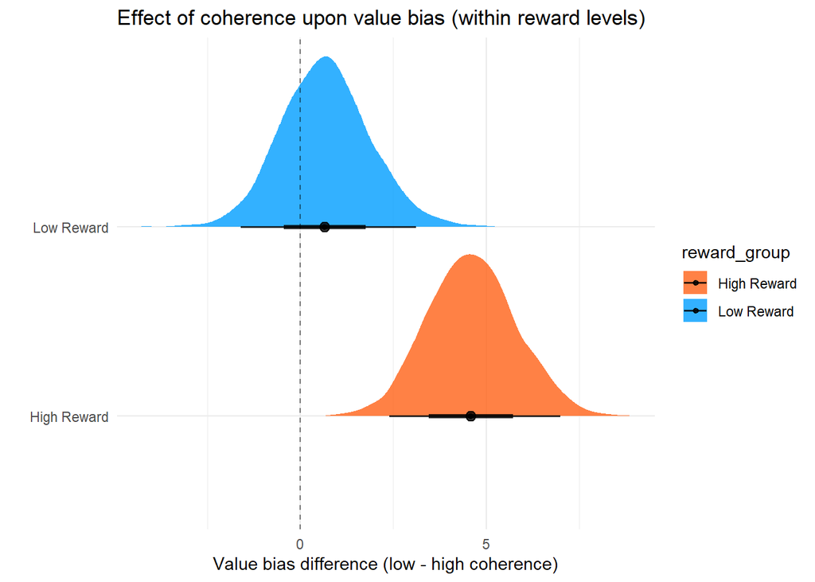

Change in value bias across coherence levels

| Condition Contrast | Median Diff | Lower 95% | Upper 95% | P-Direction |
| --- | --- | --- | --- | --- |
| hi coherence0.2 - hi coherence0.4 | 4.586 | 2.391 | 6.992 | 1.00 |
| lo coherence0.2 - lo coherence0.4 | 0.654 | -1.598 | 3.113 | 0.71 |

Value bias decreases with increasing coherence in the high-reward condition only; there’s no meaningful difference across coherence levels for low-reward trials, as in neither case is there that much of a bias to start with.

#### Effect of reward

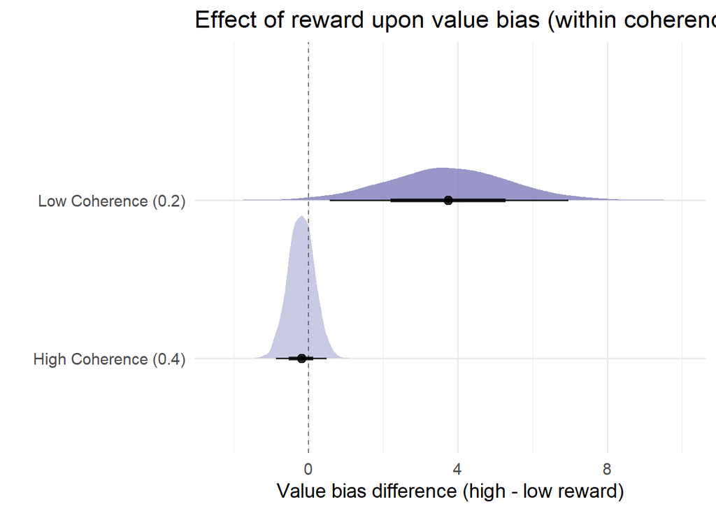

Change in value bias across reward levels (high - low)

| Coherence Level | Median Diff | 95% Lower | 95% Upper | P-Direction |
| --- | --- | --- | --- | --- |
| Low Coherence (0.2) | 3.73 | 0.58 | 6.96 | 0.99 |
| High Coherence (0.4) | -0.19 | -0.87 | 0.49 | 0.70 |

Value bias is greater in the high-reward condition than the low-reward one, only when coherence is low.

### Does response precision change across trial types?

Next, let’s see how the model has estimated *kappa* (response precision) in each reward x coherence condition.

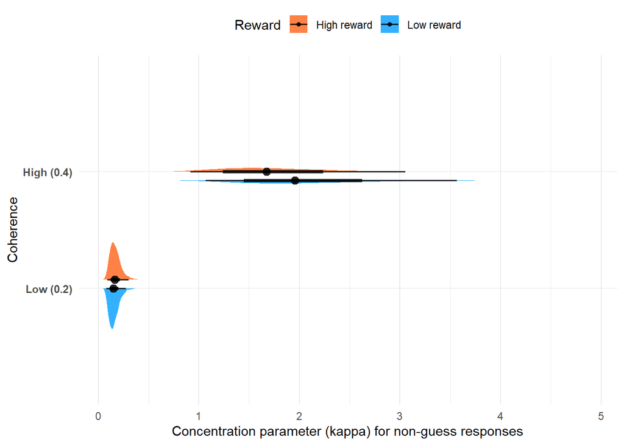

Response precision (kappa) by condition

| Coherence | Reward | Median | 95% Credible Interval 95% Lower | 95% Credible Interval 95% Upper |
| --- | --- | --- | --- | --- |
| 0.2 | lo | 0.150 | 0.082 | 0.275 |
|  | hi | 0.162 | 0.088 | 0.301 |
| 0.4 | lo | 1.955 | 1.067 | 3.565 |
|  | hi | 1.674 | 0.918 | 3.055 |

As expected, there’s a clear effect of coherence upon kappa (high-coherence trials produce a less dispersed distribution of responses); I won’t do contrasts for this as it’s pretty obvious.

Note also that with guesses filtered out, the model has found it even harder to estimate precision for the higher-coherence trials. This is another instance of identifiability issues when estimating *kappa* for tighter distributions (i.e., once a distribution is already ‘spiked,’ even massive increases in *kappa* result in almost no visible change to the response spread).

Within each level of coherence, is responding less precise for low-reward trials? In other words, are people making less of an effort when they aren’t going to win big?

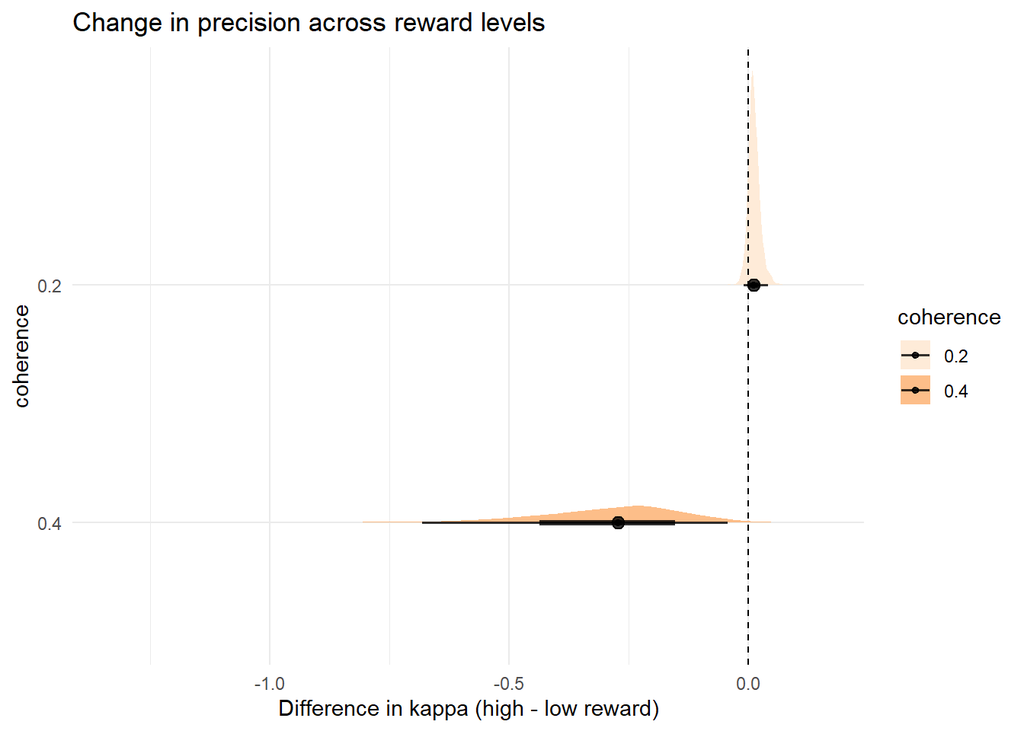

| coherence | median_diff | lower_95 | upper_95 | prob_hi_better |
| --- | --- | --- | --- | --- |
| 0.2 | 0.011 | -0.01 | 0.042 | 0.871 |
| 0.4 | -0.271 | -0.68 | -0.043 | 0.010 |

There’s no effect when coherence is low, but we get an effect in the *wrong* direction when coherence is high (i.e., people are more precise for low-value trials than high-value ones). I’ll explain more about this below, but I attribute this to an interaction with guessing proportion.

### Guessing proportion

Now, let’s look the proportion of trials for which the model thinks people are guessing within each condition.

Guessing probability by condition

| Reward | Coherence | Median | 95% Lower | 95% Upper | P-Direction |
| --- | --- | --- | --- | --- | --- |
| hi | 0.2 | 0.269 | 0.189 | 0.363 | 1 |
| hi | 0.4 | 0.296 | 0.235 | 0.365 | 1 |
| lo | 0.2 | 0.276 | 0.195 | 0.369 | 1 |
| lo | 0.4 | 0.376 | 0.306 | 0.446 | 1 |

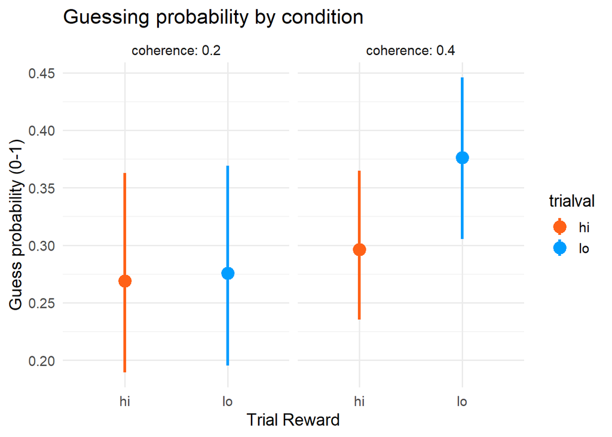

The posterior estimates don’t support a difference in guessing rate across coherence levels for high-value trials, but it *does* find that for low-reward trials, people guess more for high-coherence than low-coherence trials.

Effect of coherence on guess rate

| Reward Level | Median Diff | Lower 95% | Upper 95% | P(Increase) |
| --- | --- | --- | --- | --- |
| High Reward | -0.0280 | -0.1262 | 0.0747 | 0.3012 |
| Low Reward | -0.0991 | -0.1992 | 0.0098 | 0.0350 |

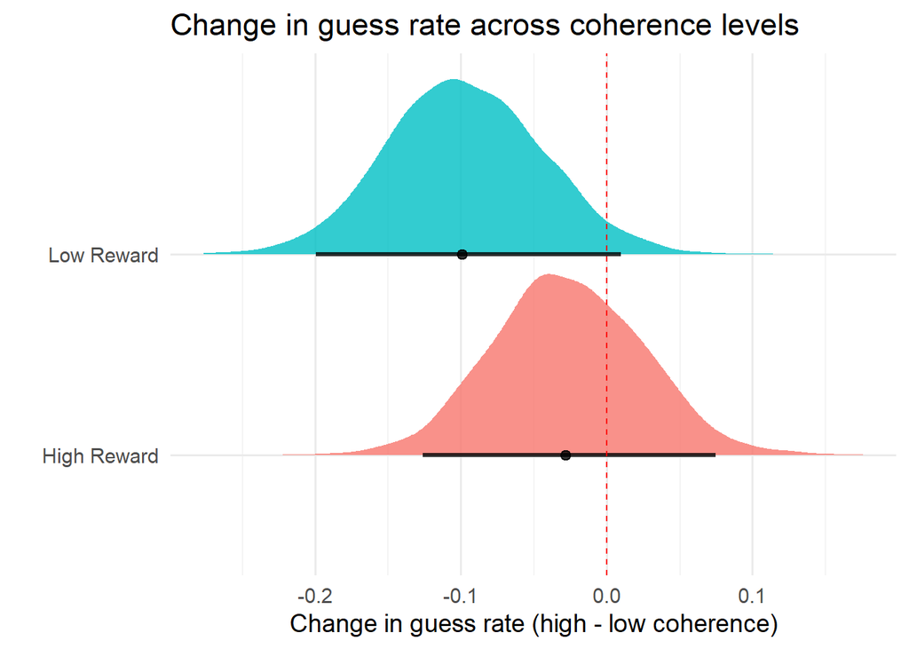

When coherence is low, the model doesn’t find support for a difference in guessing rates based on trial reward. However, when coherence is high, it finds that people guess more often on low-value trials than high-value ones.

Effect of reward on guess rate

| Coherence Level | Median Diff | Lower 95% | Upper 95% | P(Hi < Lo) |
| --- | --- | --- | --- | --- |
| High Coherence (0.4) | -0.0777 | -0.1168 | -0.0401 | 1.00 |
| Low Coherence (0.2) | -0.0081 | -0.0874 | 0.0828 | 0.57 |

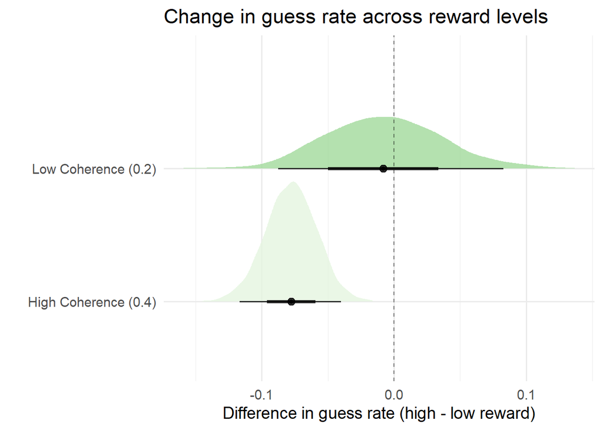

## Takeaways

It’s good to see that the model estimates the same pattern of value bias across conditions as the simpler (non-mixture) version.

However, there are some concerns here about estimation of kappa (precision) and theta (guess rate):

- The model continues to struggle with estimating response precision when coherence is high, likely due to identifiability issues. When coherence is high, it also predicts that people are more precise for low-value trials than high-value ones, which is hard to justify empirically.
- Guess rates look sensible for high-coherence trials, but they are identical regardless of trial reward when coherence is low. This is surprising and a bit concerning: as Christin and I have discussed, it likely reflects the model struggling to distinguish between guesses and low-precision responses to the target.
- Furthermore, I suspect a relationship between some of the issues for theta and kappa: for instance, when considering high-coherence trials, maybe the model thinks that precision is higher in the low-value condition just because it has filtered out more trials as guesses.

## Next steps

While there are some things which have worked well in this mixture modelling, the data seem quite ‘muddy’ (i.e., there are a lot of datapoints which are quite hard to classify as genuine responses vs. guesses). This is partially because I added in our usually-excluded ‘guessers’ on this run, but it will be an issue we need to grapple with irrespective of that.

One really important question here: is this muddiness present *within* every individual distribution, or is it an effect that we see in the dataset as a whole because of *specific participants* who are contaminating the distributions (e.g., consistently guessing or using a strategy different from the instructed one)? As discussed with Christin, I think we will get better results if we rework our modelling approach to classify participants by strategy, then only estimate our parameters of interest for the subset of people who we’re confident are doing the task as intended.